# R et les bases de données

### B.Thieurmel - benoit.thieurmel@datastorm.fr

### ENEDIS : R & SQL - 22/01/2021

[figure not shown]

[figure not shown]

[figure not shown]

# FRAMEWORK DBI

# Les packages existants

Il existe au minimum un package qui permet de se connecter à chaque type de bases de données, par exemple :

- **RMySQL** : base de données MySQL
- **RPostgres** : base de données PostgreSQL (à prioriser *vs* le package plus ancien **RPostgreSQL**, qui n’est plus maintenu et moins performant)
- **ROracle** : base de données Oracle
- **RSQLServer** : base de données MS SQL Server
- **RSQLite** : base de données SQLite
- **RJDBC** : connexion à différents types de bases de données via du Java
- **RODBC** : connexion à différents types de bases de données via du ODBC
- **mongolite** : base de données NoSQL mongodb
- ….

# DBI : syntaxe usuelle de connexion (1/2)

Le package **DBI** propose une interface commune d’utilisation des différentes bases de données.

Les autres packages comme **RMySQL** ou **RPostgres** servent alors essentiellement à fournir le *driver* permettant la connexion à la base de données correspondante.

La syntaxe usuelle d’utilisation est la suivante :

1. ouverture de la connexion avec `dbConnect()`
2. requêtage avec `dbGetQuery()`, avec le passage directement d’une requête **SQL**
3. fermeture de la connexion avec `dbDisconnect()`

# DBI : syntaxe usuelle de connexion (2/2)

```r
require(DBI)
require(RPostgres)

# ouverture d'une connexion
con <- dbConnect(RPostgres::Postgres(), # RMySQL::MySQL()
                 host = "myserver",
                 port = 123,
                 dbname = "database",
                 user = "benoit",
                 password = "security")

# exécution d'une requête et récupération du résultat
res <- dbGetQuery(con, "SELECT * FROM mytable")

# Fermeture de la connexion
dbDisconnect(con)
```

# DBI : principales fonctions

- `dbConnect()` & `dbDisconnect()` : connexion / déconnexion à la base
- `dbListTables()` & `dbListFields()` : récupération des tables disponibles et des champs présents
- `dbGetQuery()` : envoi d’une requête SQL retournant des données (`SELECT ...`) et récupération du résultat
- `dbReadTable()` & `dbWriteTable()` : lecture / écriture d’une table dans sa globalité
- `dbSendQuery()` : exécution d’une requête
  - suivie d’un `dbFetch()` si on souhaite récupérer le résultat
  - et dans tous les cas de `dbClearResult()`
  - va nous permettre notamment d’insérer des lignes / supprimer des tables, …
- …

# DBI : dbConnect

Le premier argument **obligatoire** de `dbConnect` est donc le *driver* permettant de se connecter à la base de données. Ce *driver* étant en général fourni pour le biais d’un autre package.

Les principaux paramètres de connexion sont ensuite les suivants :

- **user** : nom d’utilisateur
- **password** : mot de passe
- **host** : adresse ip ou nom de l’hôte hébergeant la base
- **port** : numéro du port ouvert de la base
- **dbname** : nom de la base de données

*Quelques exceptions cependant dans le nom des arguments, comme par exemple lors de la connexion à une base MS SQL…*

# DBI : dbGetQuery

L’utilisation de la fonction `dbGetQuery` avec le passage directe d’une requête **SQL** est ensuite la façon la plus simple d’interroger la base de données :

```r
# connexion à une base temporaire SQLite in-memory
con <- dbConnect(RSQLite::SQLite(), ":memory:")

# ecriture d'une table
dbWriteTable(con, "mtcars", mtcars)

# exécution d'une requête et récupération du résultat
res <- dbGetQuery(con, "SELECT * FROM mtcars WHERE cyl = 4");head(res, n = 2)
```

```
##    mpg cyl  disp hp drat   wt  qsec vs am gear carb
## 1 22.8   4 108.0 93 3.85 2.32 18.61  1  1    4    1
## 2 24.4   4 146.7 62 3.69 3.19 20.00  1  0    4    2
```

```r
# déconnexion
dbDisconnect(con)
```

**ATTENTION à bien respecter les règles associées à la base de données, comme l’utilisation de simple quote ’ ou la casse des caractères**

# DBI : dbSendQuery

`dbSendQuery` exécute une requête sur la connexion. Elle ne retourne pas par défaut le résultat, ce qui possible avec un `dbFetch()`, et il faut dans tous les cas finir par un `dbclearResult()` pour libérer la mémoire.

```r
# connexion à une base temporaire SQLite in-memory
con <- dbConnect(RSQLite::SQLite(), ":memory:"); dbWriteTable(con, "mtcars", mtcars)
# exécution de la requête
rs <- dbSendQuery(con, "SELECT * FROM mtcars WHERE cyl = 4"); rs
```

```
## <SQLiteResult>
##   SQL  SELECT * FROM mtcars WHERE cyl = 4
##   ROWS Fetched: 0 [incomplete]
##        Changed: 0
```

```r
# récupération du résultat
data <- dbFetch(rs); head(data, n = 2)
```

```
##    mpg cyl  disp hp drat   wt  qsec vs am gear carb
## 1 22.8   4 108.0 93 3.85 2.32 18.61  1  1    4    1
## 2 24.4   4 146.7 62 3.69 3.19 20.00  1  0    4    2
```

```r
# nettoyage & déconnexion
dbClearResult(rs) ; dbDisconnect(con)
```

# SECURISER LES INFORMATIONS DE CONNEXION

# Via une fenêtre utilisateur ?

Dans RStudio avec `rstudioapi::askForPassword()`, ou avec `getPass::getPass()`

```r
# ouverture d'une connexion
con <- dbConnect(RPostgres::Postgres(),
                 host = "myserver",
                 port = 123,
                 dbname = "database",
                 user = "benoit",
                 password = rstudioapi::askForPassword("Database password"))
```

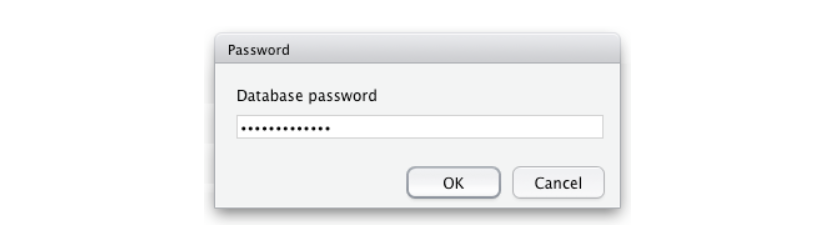

# avec les options dans R ?

Dans un script **privé et non partagé**, définir des options de connexion :

```r
options(database_userid = "myuserid")
options(database_password = "mypassword")
```

Puis dans le script **principal et partagé** :

```r
# ouverture d'une connexion
con <- dbConnect(RPostgres::Postgres(),
                 host = "myserver",
                 port = 123,
                 dbname = "database",
                 user = getOption("database_userid"),
                 password = getOption("database_password"))
```

# avec des variables d’environnement ?

Même principe qu’avec les options, sauf que les variables d’environnement doivent être définies directement sur la machine, ou bien dans le fichier *.Renviron* présent à la racine.

```r
# .Renviron
database_userid = "username"
database_password = "password"
```

Puis dans le script **principal et partagé** :

```r
# ouverture d'une connexion
con <- dbConnect(RPostgres::Postgres(),
                 host = "myserver",
                 port = 123,
                 dbname = "database",
                 user = Sys.getenv("database_userid"),
                 password = Sys.getenv("database_password"))
```

# dans un fichier YAML ?

**exemple.yml :**

```r
# Liste de configuration pour une base de données
db:
  host : 10.244.36.68
  port : 5432
  uid : user
  pwd : pwd
  dbname : database
```

Dans R, on charge ensuite le fichier avec la fonction `yaml.load_file` :

```r
require(yaml)
conf <- yaml.load_file("exemple.yml")
con <- dbConnect(RPostgres::Postgres(),
                 host = conf$db$host, port = conf$db$port,
                 dbname = conf$db$dbname, user = conf$db$uid,
                 password = conf$db$pwd)
```

# avec le package config ?

Le package **config** facilite la gestion d’environnements spécifiques, en se basant simplement sur une fichier `config.yml`.

- par défaut, **config** cherchera ce fichier dans le répertoire de travail courant. Mais nous pouvons également passer le chemin du fichier.

Plus d’informations : https://cran.r-project.org/web/packages/config/vignettes/introduction.html

# SECURISER LES REQUETES

# Concaténation avec paste ?

Dès lors que l’on souhaite développer des requêtes paramétrables, il est facile et tentant d’utiliser simplement la fonction `paste` pour créer la requête finale.

```r
cyl_subset <- 4
# exécution de la requête
res <- dbGetQuery(con,
  paste(
    "SELECT * FROM mtcars WHERE cyl = ",
    cyl_subset
  )
)
```

**Cela amène potentiellement une faille de sécurité car, sans contrôles préalables des arguments passés, l’utilisateur peut très bien insérer une reqûete dangereuse et commettre une attaque…**

Il est donc conseillé d’utiliser des requêtes dîtes **paramétrables**, ce qui possible de plusieurs façons :

- en utilisant `dbSendQuery()` et `dbBind()`
- ou le package **glue** et la fonction `glue_sql()`

# dbSendQuery & dbBind (1/2)

1. création d’une requête avec `dbSendQuery`, en utilisant des `?` pour le/les paramètre(s)
2. utilisation de `dbBind` pour passer la/les valeur(s)
3. récupération avec `dbFetch`
4. Appels multiples possibles

```r
# un argument simple
con <- dbConnect(RSQLite::SQLite(), ":memory:")
dbWriteTable(con, "mtcars", mtcars)

simple_bind <-  dbSendQuery(con, "SELECT * FROM mtcars WHERE cyl = ?")
dbBind(simple_bind, list(4))
head(dbFetch(simple_bind), n = 2)
```

```
##    mpg cyl  disp hp drat   wt  qsec vs am gear carb
## 1 22.8   4 108.0 93 3.85 2.32 18.61  1  1    4    1
## 2 24.4   4 146.7 62 3.69 3.19 20.00  1  0    4    2
```

# dbSendQuery & dbBind (2/2)

```r
# plusieurs arguments simples
con <- dbConnect(RSQLite::SQLite(), ":memory:")
dbWriteTable(con, "mtcars", mtcars)

multiple_bind <-  dbSendQuery(con, "SELECT * FROM mtcars WHERE cyl = ? AND am = ?")
dbBind(multiple_bind, list(4, 0))
head(dbFetch(multiple_bind), n = 2)
```

```
##    mpg cyl  disp hp drat   wt qsec vs am gear carb
## 1 24.4   4 146.7 62 3.69 3.19 20.0  1  0    4    2
## 2 22.8   4 140.8 95 3.92 3.15 22.9  1  0    4    2
```

```r
# second appel
dbBind(multiple_bind, list(4, 1))
head(dbFetch(multiple_bind), n = 2)
```

```
##    mpg cyl  disp hp drat   wt  qsec vs am gear carb
## 1 22.8   4 108.0 93 3.85 2.32 18.61  1  1    4    1
## 2 32.4   4  78.7 66 4.08 2.20 19.47  1  1    4    1
```

**Inconvénient majeur :** : impossible de passer des arguments plus complexes, comme des ensembles de valeurs pour l’opérateur SQL `IN` par exemple

# glue_sql (1/2)

1. création de la requête avec `glue_sql`, en utilisant des `{nom_var}` pour le/les paramètre(s)
2. récupération directement avec `dbGetQuery`

```r
# un argument simple
con <- dbConnect(RSQLite::SQLite(), ":memory:")
dbWriteTable(con, "mtcars", mtcars)

simple_glue <- glue::glue_sql(
  "SELECT * FROM mtcars WHERE cyl = {val_cyl}",
  val_cyl = 4, # passage des variables
  .con = con # et de la connexion
)

simple_glue
```

```
## <SQL> SELECT * FROM mtcars WHERE cyl = 4
```

```r
head(dbGetQuery(con, simple_glue), 2)
```

```
##    mpg cyl  disp hp drat   wt  qsec vs am gear carb
## 1 22.8   4 108.0 93 3.85 2.32 18.61  1  1    4    1
## 2 24.4   4 146.7 62 3.69 3.19 20.00  1  0    4    2
```

# glue_sql (2/2)

**glue** va gérer les arguments plus complexes avec l’ajout d’un * et l’utilisation de parenthèses`({nom_var*})`

```r
# deux arguments, dont un complexe
con <- dbConnect(RSQLite::SQLite(), ":memory:")
dbWriteTable(con, "mtcars", mtcars)

multiple_glue <- glue::glue_sql(
  "SELECT * FROM mtcars WHERE cyl IN ({val_cyl*}) AND am = {val_am}",
  val_cyl = c(4,6),
  val_am = 0,
  .con = con
)

multiple_glue
```

```
## <SQL> SELECT * FROM mtcars WHERE cyl IN (4, 6) AND am = 0
```

```r
head(dbGetQuery(con, multiple_glue), 2)
```

```
##    mpg cyl disp  hp drat    wt  qsec vs am gear carb
## 1 21.4   6  258 110 3.08 3.215 19.44  1  0    3    1
## 2 18.1   6  225 105 2.76 3.460 20.22  1  0    3    1
```

# DBPLYR

# dbplyr, c’est quoi ?

[dbplyr](https://dbplyr.tidyverse.org/)

[dplyr cheatsheet](https://rstudio.com/wp-content/uploads/2015/02/data-wrangling-cheatsheet.pdf)

[Manipuler les donnees avec dplyr](http://larmarange.github.io/analyse-R/manipuler-les-donnees-avec-dplyr.html)

# Les bases de dplyr : sélection des colonnes

`select` permet de sélectionner des colonnes d’un tableau de données

- les noms sans quote, avec un `-` devant si on veut plutôt enlever certaines colonnes, ou en utilisant l’opérateur `:` pour une plage

```r
mtcars %>% select(cyl, disp) # uniquement cyl et disp
mtcars %>% select(-cyl, -disp) # tout sauf cyl et disp
mtcars %>% select(cyl:wt) # de cyl à wt
```

- en utilisant des chaînes de caractères et `any_of` ou `all_of`

```r
mtcars %>% select(any_of(c("cyl", "disp"))) # dyl et disp
```

- avec des expressions régulières et les fonctions `starts_with`, `ends_width`, `contains` ou `matches`

```r
mtcars %>% select(starts_with("c")) # les colonnes commençant par c
```

# Les bases de dplyr : filtre sur les lignes

`filter` permet de filtrer les lignes à conserver

- en passant une ou plusieurs expressions **R** qui retournent des booléans (`>=`, `==`, `!=`, `%in%`, …)
- dans le cas de plusieurs expressions, elles seronts combinées avec le `&` logique

```r
mtcars %>% filter(am == 0) # renvoie les lignes avec am = 0
mtcars %>% filter(am == 0 | am == 1) # am = 0 ou am = 1
mtcars %>% filter(am == 0 & vs == 1) # am = 0 et vs = 1
mtcars %>% filter(am == 0, vs == 1) # am = 0 et vs = 1
```

- et on peut utiliser toutes les fonctions **R** disponibles

```r
mtcars %>% filter(mpg == max(mpg))
```

- utilisation des noms de colonnes en caractères ? avec `.data`, qui fait référence à l’ensemble des données (`list`)

```r
var = "am" ; value = 0
mtcars %>% filter(.data[[var]] == value)
```

# Les bases de dplyr : ordonner les données

`arrange` permet d’ordonner les données

- Par défaut par ordre croissant, en utilisant le nom de la colonne sans quote

```r
mtcars %>% arrange(mpg) # tri par mpg croissant
mtcars %>% arrange(am, mpg) # am croissant, puis mpg croissant
```

- utilisation des `desc` pour un tri décroissant

```r
mtcars %>% arrange(desc(mpg)) # tri par mpg desc
mtcars %>% arrange(desc(am), mpg) # am desc, puis mpg croissant
```

- `.data` avec des chaînes de caractères

```r
var <- "mpg"
mtcars %>% arrange(desc(.data[[var]]))
```

# Les bases de dplyr : créer des nouvelles colonnes

`mutate` permet de créer une ou plusieurs nouvelles colonnes. **Syntaxe :** nom (avec ou sans quote) = expression

```r
mtcars %>% mutate(wt_sq = wt ^ 2) # ajout de wt au carrée
mtcars %>% mutate("wt_sq" = wt ^ 2) # idem
```

- plusieurs colonnes à la suite, les colonnes étant créer dans l’ordre, elles sont donc disponibles si besoin pour la création des colonnes suivantes

```r
mtcars %>% mutate(wt_sq = wt ^ 2, wt_sq_sup10 = wt_sq > 10)
```

- et toujours `.data` avec des chaînes de caractères…!

```r
var <- "wt" ; mtcars %>% mutate(wt_sq = .data[[var]] ^ 2)
```

- conditions multiples ? `case_when`

```r
mtcars %>% mutate(am_vs = case_when(
  am == 0 & vs == 0 ~ "Nothing", am == 0 & vs == 1 ~ "Vs only",
  am == 1 & vs == 0 ~ "Am only", am == 1 & vs == 1 ~ "Am & Vs",
  TRUE ~ "Other" # valeur par défaut
))
```

# Les bases de dplyr : agrégation par sous-population (1/2)

La fonction `group_by` va nous permettre de définir les sous-population sur lesquelles nous allons pouvoir effectuer des opérations

- En enchaînant sur un `mutate`, nous calculerons par exemple une nouvelle variable pour chaque sous-population et le résultat sera affecté à l’ensemble du jeu de données initial

```r
# on enchaîne les opérations avec %>%
# le group_by doit placé avant le mutate
mtcars_mod <- mtcars %>% group_by(cyl) %>%
  mutate(mean_mpg = mean(mpg)) %>%
  select(mpg, cyl, mean_mpg)
head(mtcars_mod, n = 4)
```

```
## # A tibble: 4 x 3
## # Groups:   cyl [2]
##     mpg   cyl mean_mpg
##   <dbl> <dbl>    <dbl>
## 1  21       6     19.7
## 2  21       6     19.7
## 3  22.8     4     26.7
## 4  21.4     6     19.7
```

# Les bases de dplyr : agrégation par sous-population (2/2)

- En enchaînant sur un `summarize`, on pourra calculer des indicateurs sur nos sous-populations et récupérer directement le tableau agrégé (`summarize` peut être utiliser sur l’ensemble des données, sans `group_by`)
- Les colonnes définissant les sous-populations seront par défaut présentes dans le résultat
- Utilisation de la fonction `n()` pour compter le nombre de lignes

```r
mtcars %>% group_by(am, vs) %>%
  summarise(
    min_mpg = min(mpg),
    max_mpg = max(mpg),
    n_rows = n()
  )
```

```
## # A tibble: 4 x 5
## # Groups:   am [2]
##      am    vs min_mpg max_mpg n_rows
##   <dbl> <dbl>   <dbl>   <dbl>  <int>
## 1     0     0    10.4    19.2     12
## 2     0     1    17.8    24.4      7
## 3     1     0    15      26        6
## 4     1     1    21.4    33.9      7
```

# Les bases de dplyr : autres fonctions utiles

- `slice()` : sélectionner des lignes du tableau selon leur position
- `relocate()` : changer l’ordre des colonnes, `rename()` : changer le noms des colonnes
- `sample_n()` et `sample_frac()` : sélectionner un échantillon aléatoire
- `lead()` et `lag()` : créer des variables décalées
- `distinct()` : conserver uniquement les observations uniques

**fusion de tables**

- `inner_join()` : les lignes présentes dans le premier jeu de données *x* **ET** le seconde jeu de données *y* sont conservées dans la table finale, par rapport aux clefs définies
- `full_join()` : les lignes présentes dans le premier jeu de données *x* **OU** le seconde jeu de données *y*
- `left_join()` : les lignes présentes uniquement dans *x*
- `right_join()` : les lignes présentes uniquement dans *y*